# Métodos Inferenciais em Pesquisas Legislativas

Leandro Carísio Fernandes

## Ambiente R

Caso ainda não tenha instalado a linguagem R e o ambiente RStudio, baixe os arquivos e efetue a instalação:

- [R 4.1.3](https://cran.r-project.org/bin/windows/base/)
- [RStudio 2022.02.1-461](https://www.rstudio.com/products/rstudio/download/)

Antes de prosseguir:

- crie uma pasta chamada “ListaMIPL” na área de trabalho;
- configure essa pasta como diretório de trabalho, selecionando o menu “Session->Set Working Directory->Choose Directory…”, ou pressionando as teclas “Ctrl+Shift+H”;

## Atividade

Agora vamos analisar um conjunto de dados real de dados eleitorais referentes às eleições de 2016.

1. Consulte o Repositório de Dados Eleitorais do TSE https://dadosabertos.tse.jus.br/dataset/, acesse a área **Etiquetas**, selecione **Ano 2016** e o conjunto de dados **Candidatos - 2016**.
2. Selecione o link **Bens de candidatos** e baixe o arquivo **bem_candidato_2016.zip** para a pasta de trabalho definida no RStudio. Do arquivo baixado, extraia os arquivos **bem_candidato_2016_BRASIL.csv** e **leiame.pdf**. Consulte o dicionário de dados (arquivo leiame.pdf) e conheça a estrutura do arquivo descompactado.
3. Retorne á área **Candidatos - 2016**, selecione o link **Candidatos** e baixe o arquivo **consulta_cand_2016.zip** para a pasta de trabalho. Do arquivo baixado, extraia os arquivos **consulta_cand_2016_BRASIL.csv** e **leiame.pdf**. Consulte o dicionário de dados (arquivo leiame.pdf) e conheça a estrutura do arquivo descompactado.
4. Leia os arquivos **bem_candidato_2016_BRASIL.csv** e **consulta_cand_2016_BRASIL.csv**, crie os *data frames* **bemCand** e **cand**, respectivamente, mostre as quantidades de linhas e colunas e verifique se existem valores não informados nesses conjuntos de dados.

```r
# leitura do arquivo 1

# De acordo com a documentação (arquivo leiame.pdf) os campos preenchidos como #NULO ou #NE (string) e os campos preenchidos com -1 e -3 (numéricos) indicam valores não disponíveis (ou não informado ou não registrado na época).
# Por isso é necessário informar esses valores no parâmetro na.strings na hora de ler o arquivo. Como o csv contém dados entre aspas, por precaução
# vamos considerar também as strings "-1" e "-3"

bemCand = read.csv2('bem_candidato_2016_BRASIL.csv', na.strings=c("#NULO#", "#NE#", "-1", "-3", -1, -3))

# linhas e colunas
linhas_bem_cand = nrow(bemCand)
colunas_bem_cand = ncol(bemCand)

# valores não informados
# Existem 949 registros com missing values e todos estão no campo DS_BEM_CANDIDATO (Descrição dos bens dos candidatos)
num_registros_bem_cand_com_na = nrow(bemCand[rowSums(is.na(bemCand)) > 0,])

# leitura do arquivo 2

# De acordo com a documentação (arquivo leiame.pdf) os campos preenchidos como #NULO ou #NE (string) e os campos preenchidos com -1 e -3 (numéricos) indicam valores não disponíveis (ou não informado ou não registrado na época). Por isso é necessário informar esses valores no parâmetro na.strings na hora de ler o arquivo.
cand = read.csv2('consulta_cand_2016_BRASIL.csv', na.strings=c("#NULO#", "#NE#", "-1", "-3", -1, -3))

# linhas e colunas
linhas_cand = nrow(cand)
colunas_cand = ncol(cand)

# valores não informados
# Todos os registros informados possuem algum missing value. De fato, podemos observar que a variável CD_MUNICIPIO_NASCIMENTO está com -3 para todos os candidatos, ou seja, a informação não era registrada em banco de dados pelos sistemas eleitorais. Mesmo se desconsiderarmos essa coluna, há NA em outros campos, como o campo NM_SOCIAL_CANDIDATO que possui quase todos os registros como #NULO#  (exceto 57 registros)
num_registros_cand_com_na = nrow(cand[rowSums(is.na(cand)) > 0,])
```

Respostas:

5. Apresente as seguintes informações:
- quantidade de unidades eleitorais apuradas em 2016;
- lista dos tipos de bens levantados pelo TSE;
- histograma dos valores de bens referentes a embarcações.

```r
# quantidade de unidades eleitorais apuradas em 2016
qtd_ue = length(unique(cand$SG_UE))

# lista dos tipos de bens levantados pelo TSE
# Primeiro checamos a existência de NA nesse campo...
sum(is.na(bemCand$DS_TIPO_BEM_CANDIDATO))
```

```
## [1] 0
```

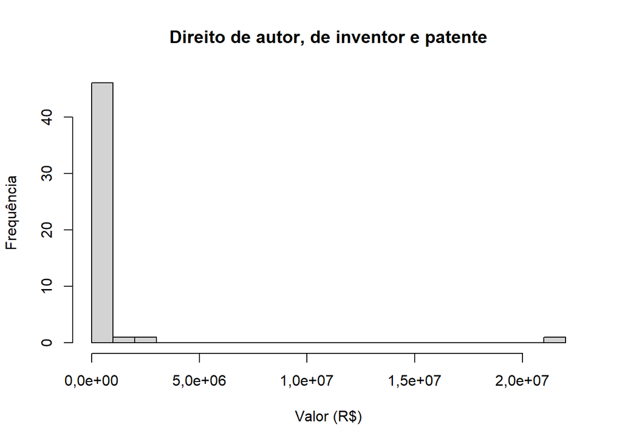

```r
# ... como não existe NA, então vamos pegar direto os tipos únicos:
lista_tipos_bens = sort(unique(bemCand$DS_TIPO_BEM_CANDIDATO))

# histograma dos valores de bens referentes a direito de autor, de inventor e patente
dados_direito_autor_inventor_patente = bemCand[bemCand$DS_TIPO_BEM_CANDIDATO == "Direito de autor, de inventor e patente",]
hist(dados_direito_autor_inventor_patente$VR_BEM_CANDIDATO, breaks = 20, xlab="Valor (R$)", ylab="Frequência", main="Direito de autor, de inventor e patente")
```

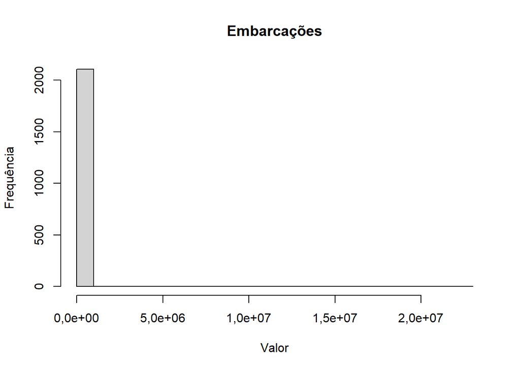

```r
# histograma dos valores de bens referentes a embarcações
dados_embarcacoes = bemCand[bemCand$DS_TIPO_BEM_CANDIDATO == "Embarcação",]
hist(dados_embarcacoes$VR_BEM_CANDIDATO, breaks = 20, xlab="Valor", ylab="Frequência", main="Embarcações")
```

Respostas:

A quantidade de unidades eleitorais apuradas em 2016 foi de 5.568.

Os tipos de bens apurados pelo TSE em 2016 foram:

```r
kable(lista_tipos_bens, col.names=c("Tipos de bens apurados em 2016 pelo TSE"))
```

| Tipos de bens apurados em 2016 pelo TSE |
| --- |
| Ações (inclusive as provenientes de linha telefônica) |
| Aeronave |
| Apartamento |
| Aplicação de renda fixa (CDB, RDB e outros) |
| Bem relacionado com o exercício da atividade autônoma |
| Benfeitorias |
| Caderneta de poupança |
| Casa |
| Consórcio não contemplado |
| Construção |
| Crédito decorrente de alienação |
| Crédito decorrente de empréstimo |
| Depósito bancário em conta corrente no exterior |
| Depósito bancário em conta corrente no País |
| Dinheiro em espécie - moeda estrangeira |
| Dinheiro em espécie - moeda nacional |
| Direito de autor, de inventor e patente |
| Direito de lavra e assemelhado |
| Embarcação |
| Fundo de ações, inclusive Carteira Livre e Fundo de Investimento no exterior |
| Fundo de aplicação em quotas de fundos de investimento |
| Fundo de capitalização |
| Fundo de Curto Prazo |
| Fundo de investimento financeiro - FIF |
| Fundo de Investimento Imobiliário |
| Fundo de Longo Prazo e Fundo de Investimentos em Direitos Creditórios (FIDC) |
| Fundos: Ações, Mútuos de Privatização, Invest. Empresas Emergentes, Invest.Participação e Invest. Índice Mercado |
| Galpão |
| Jóia, quadro, objeto de arte, de coleção, antiguidade, etc. |
| Leasing |
| Licença e concessões especiais |
| Linha telefônica |
| Loja |
| Mercado futuros, de opções e a termo |
| Ouro, ativo financeiro |
| Outras aplicações e Investimentos |
| Outras participações societárias |
| Outros bens e direitos |
| OUTROS BENS E DIREITOS |
| Outros bens imóveis |
| Outros bens móveis |
| Outros créditos e poupança vinculados |
| Outros depósitos à vista e numerário |
| Outros fundos |
| Plano PAIT e caderneta de pecúlio |
| Poupança para construção ou aquisição de bem imóvel |
| Prédio comercial |
| Prédio residencial |
| Quotas ou quinhões de capital |
| Sala ou conjunto |
| Terra nua |
| Terreno |
| Título de clube e assemelhado |
| Veículo automotor terrestre: caminhão, automóvel, moto, etc. |
| VGBL - Vida Gerador de Benefício Livre |

Em relação ao histograma, o enunciado do exercício pede de embarcações, mas o comentário no esqueleto do código pede o histograma relacionado a direito de autor, de inventor e patente. Por isso foi exibido o histograma dos dois tipos de bens nas figuras acima.

O histograma de embarcações parece mostrar que tudo está concentrado no primeiro bin. Os dados mostram um total de 2.108 registros de embarcações sendo que uma delas foi declarada com valor de aproximadamente R$ 22 milhões, 3 embarcações acima de R$ 1 milhão e todas as outras com valores abaixo disso. Com isso, o histograma mostra a concentração de dados no primeiro bin e passa a ideia visual de que os outros estão vazios (o que não é verdade). Algo semelhante ocorre com o histograma de direito de autor, de inventor e patente.

6. Investigue as formas de extração de subconjuntos de dados a partir de um conjunto maior por meio do pacote **dplyr**. consulte [Introdução ao Dplyr](https://analisereal.com/tag/dplyr/)), com atenção ao item **Agrupando e sumarizando**. Também a aula [Manipulação de dados utilizando o pacote dplyr](https://www.youtube.com/watch?v=D83BvonKAFM) é bastante útil. Você precisará dos pacotes **dplyr** e **tidyr**, que serão instalados pelo código abaixo, caso ainda não estejam disponíveis no ambiente RStudio.

```r
suppressWarnings(suppressMessages( if(!require(dplyr)) { install.packages('dplyr') }  ))
suppressWarnings(suppressMessages( if(!require(tidyr)) { install.packages('tidyr') }  ))

library(dplyr)
library(tidyr)
```

7. Crie um subconjubto de dados chamado **agregado**, contendo os campos SQ_CANDIDATO, SG_UF, NM_UE e VR_TOTAL_BENS, onde VR_TOTAL_BENS é o valor total do patrimônio declarado pelo candidato. Liste os **vinte** candidatos com o **maior** patrimônio declarado e **todos** os candidatos com o menor patrimônio declarado.

```r
agregado = bemCand %>%
    # Seleciona apenas os campos solicitados pelo exercício
    select(SQ_CANDIDATO, SG_UF, NM_UE, VR_BEM_CANDIDATO) %>%
    # Agrupa por candidato
    group_by(SQ_CANDIDATO) %>%
    # Cria uma coluna VR_TOTAL_BENS com a soma de todos os bens do candidato
    mutate(VR_TOTAL_BENS = sum(VR_BEM_CANDIDATO)) %>%
    # Remove a coluna VR_BEM_CANDIDATO
    select(-VR_BEM_CANDIDATO) %>%
    # Remove as duplicatas
    distinct %>%
    # Ordena por valor total de bens
    arrange(desc(VR_TOTAL_BENS))

candidatos_maiores_patrimonios = cand[cand$SQ_CANDIDATO %in% agregado$SQ_CANDIDATO[1:20], c("SQ_CANDIDATO", "NM_CANDIDATO")]
candidatos_maiores_patrimonios = merge(agregado, candidatos_maiores_patrimonios)
candidatos_maiores_patrimonios = candidatos_maiores_patrimonios %>% arrange(desc(VR_TOTAL_BENS))
nome_20_candidatos_maiores_patrimonios = candidatos_maiores_patrimonios$NM_CANDIDATO


sq_candidato_menor_patrimonio = agregado$SQ_CANDIDATO[agregado$VR_TOTAL_BENS == min(agregado$VR_TOTAL_BENS)]
nome_todos_candidatos_com_menor_patrimonio = cand$NM_CANDIDATO[cand$SQ_CANDIDATO %in% sq_candidato_menor_patrimonio]
```

Respostas:

Os 20 candidatos com maior patrimônio são (ordenados por patrimônio):

```r
kable(nome_20_candidatos_maiores_patrimonios, col.names = c('Os 20 candidatos com os maiores patrimônios'))
```

| Os 20 candidatos com os maiores patrimônios |
| --- |
| ANTONIO GUIMARÃES DA SILVA |
| JOSE RADI NETO |
| ANTONIO FERNANDES DE MELO FILHO |
| MARIA VANUZIA MENDES SANTOS |
| INALDO DOS SANTOS TEIXEIRA |
| DELCICK NUNES DE ALMEIDA |
| JOANIR MARTINS COELHO |
| CARLOS HUMBERTO HORST |
| AURELIO TEIXEIRA ERVILHA NETO |
| IDELZUITE BRITO DA LUZ FONTES |
| MARIA DE FÁTIMA RODRIGUES NUNES |
| AIRTON GARCIA FERREIRA |
| OTAVIANO OLAVO PIVETTA |
| VITTORIO MEDIOLI |
| TANIA MARA PRESTES COELHO |
| LEIDIVALDO DE SOUZA LOBO |
| LUIS FERNANDO CARVALHO LIMA |
| GENIL CONCEIÇÃO |
| ROSIANY PEIXOTO GOMES |
| ANTIDIO ALEIXO LUNELLI |

O menor valor de patrimônio declarado pelos candidatos foi de R$ 0. Os seguintes candidatos declararam esse valor:

```r
kable(nome_todos_candidatos_com_menor_patrimonio, col.names = c('Candidatos sem patrimônio declarado'))
```

| Candidatos sem patrimônio declarado |
| --- |
| ADILSON ANTONIO REZENDE |
| EDILON APARECIDO MARTINS |
| FELIPE GOMES DE MELO NETO |
| KAROLAYNE RIBEIRO MATEUS |
| ADELINO ADRIANO MENDES GULART |
| ANA MARIA DOMINGOS DE ARAUJO |
| ANA CAROLINE DE SÁ |
| ODAIR JOSÉ DE SANTANA |
| KAROLAINE SILVA MEIRELES |
| PATRICIA RODRIGUES DOS SANTOS ENGELENDER |
| ANDERSON DE OLIVEIRA DUTRA |
| LUCICLEIDE DOS SANTOS SILVA |
| ERNAINE JANUÁRIO DA SILVA |

8. Mostre os histogramas dos valores patrimoniais totais dos candidatos nas cidades de BELO HORIZONTE e PARANAGUÁ.

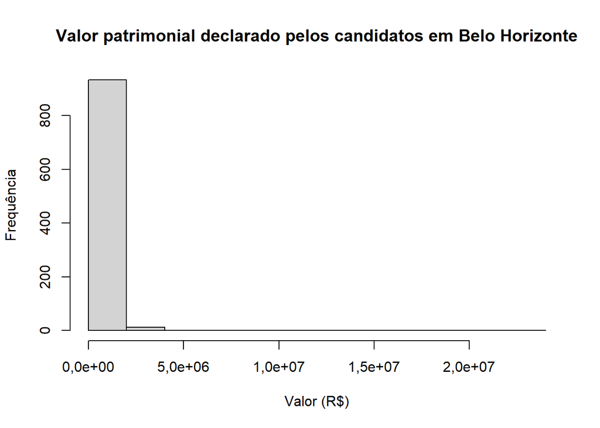

```r
agregado_bh = agregado %>%
              filter(NM_UE == 'BELO HORIZONTE')
hist(agregado_bh$VR_TOTAL_BENS, xlab="Valor (R$)", ylab="Frequência", main="Valor patrimonial declarado pelos candidatos em Belo Horizonte")
```

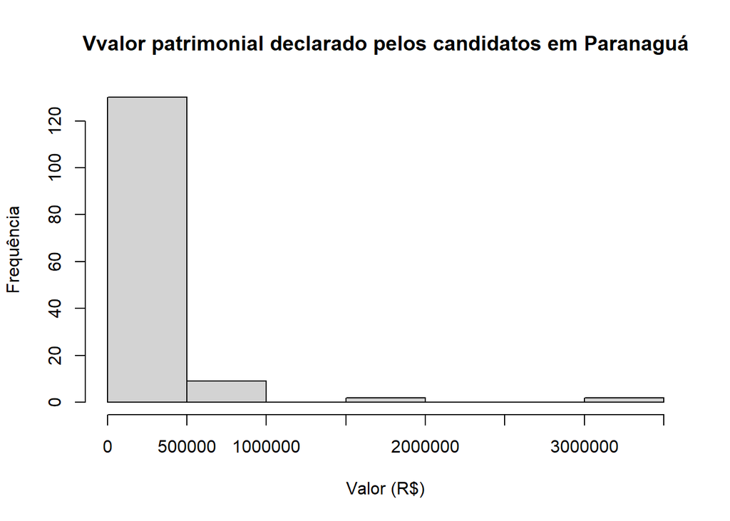

```r
agregado_paranagua = agregado %>%
              filter(NM_UE == 'PARANAGUÁ')
hist(agregado_paranagua$VR_TOTAL_BENS, xlab="Valor (R$)", ylab="Frequência", main="Vvalor patrimonial declarado pelos candidatos em Paranaguá")
```

1. Retire do *data frame* **cand** os registros referentes ao segundo turno da eleição e mostre as quantidades de linhas e colunas resultantes.

```r
cand = cand %>%
  # Retirar o segundo turno é o mesmo que filtrar apenas o primeiro turno
  filter(NR_TURNO == 1)
nrow(cand)
```

```
## [1] 498112
```

```r
ncol(cand)
```

```
## [1] 63
```

Resposta:

O dataframe cand contém 498.112 linhas e 63 colunas referentes ao primeiro turno das eleições.

10. O código abaixo acrescenta a coluna **VR_TOTAL_BENS** ao *data frame* **cand**, por meio da função **merge** (consulte [Tudo sobre Joins (merge) em R](https://www.fulljoin.com.br/posts/2016-05-12-tudo-sobre-joins/) para saber mais). Liste o nome, a unidade eleitoral, o partido e o valor patrimonial dos vinte candidatos com maior valor declarado.

```r
cand <- merge(cand,agregado[,c("SQ_CANDIDATO", "VR_TOTAL_BENS")], by = "SQ_CANDIDATO", all = TRUE)

# Ordena o dataframe por VR_TOTAL_BENS
cand <- cand %>% arrange(desc(VR_TOTAL_BENS))

nome_20_candidatos_maiores_patrimonios = cand$NM_CANDIDATO[1:20]
```

O nome dos candidatos com os maiores patrimônios delcarados é:

```r
kable(nome_20_candidatos_maiores_patrimonios, col.names="Os 20 candidatos com os maiores patrimônios")
```

| Os 20 candidatos com os maiores patrimônios |
| --- |
| ANTONIO GUIMARÃES DA SILVA |
| JOSE RADI NETO |
| ANTONIO FERNANDES DE MELO FILHO |
| MARIA VANUZIA MENDES SANTOS |
| INALDO DOS SANTOS TEIXEIRA |
| DELCICK NUNES DE ALMEIDA |
| JOANIR MARTINS COELHO |
| CARLOS HUMBERTO HORST |
| AURELIO TEIXEIRA ERVILHA NETO |
| IDELZUITE BRITO DA LUZ FONTES |
| MARIA DE FÁTIMA RODRIGUES NUNES |
| AIRTON GARCIA FERREIRA |
| OTAVIANO OLAVO PIVETTA |
| VITTORIO MEDIOLI |
| TANIA MARA PRESTES COELHO |
| LEIDIVALDO DE SOUZA LOBO |
| LUIS FERNANDO CARVALHO LIMA |
| GENIL CONCEIÇÃO |
| ROSIANY PEIXOTO GOMES |
| ANTIDIO ALEIXO LUNELLI |

11. Liste os dez partidos com maior patrimônio declarado pelos candidatos?

```r
valor_por_partido = cand %>%
    # Seleciona apenas a sigla do partido e o valor total dos bens
    select(SG_PARTIDO, VR_TOTAL_BENS) %>%
    # Agrupa por partido
    group_by(SG_PARTIDO) %>%
    # Cria uma coluna com o valor total de bens por partido. Desconsidera NA
    mutate(VR_TOTAL_BENS_POR_PARTIDO_MILHOES = sum(VR_TOTAL_BENS, na.rm=TRUE)/1e6) %>%
    # Remove a coluna de VR_TOTAL_BENS (que representa o candidato)
    select(-VR_TOTAL_BENS) %>%
    # Remove duplicatas
    distinct %>%
    # Organiza do maior pro menor
    arrange(desc(VR_TOTAL_BENS_POR_PARTIDO_MILHOES))

dez_partidos_com_maior_valor_declarado = valor_por_partido[1:10,]
```

Resposta:

```r
kable(dez_partidos_com_maior_valor_declarado, col.names=c("Partido", "Valor total declarado pelos candidatos (R$ milhões)"))
```

| Partido | Valor total declarado pelos candidatos (R$ milhões) |
| --- | --- |
| PMDB | 10807 |
| PR | 8275 |
| PSDB | 7615 |
| PP | 5594 |
| PSB | 5430 |
| PSD | 5192 |
| PDT | 4783 |
| PPS | 4628 |
| PATRIOTA | 3945 |
| DEM | 3855 |

12. Qual é o quantitativo de candidatos por raça nos estados de Alagoas, São Paulo e Paraná?

```r
cand_por_raca_al = cand %>%
    # Filtra Alagoas
    filter(SG_UF == 'AL') %>%
    # Seleciona apenas a coluna DS_COR_RACA
    select(DS_COR_RACA) %>%
    # Conta a frequência de cada grupo
    count(DS_COR_RACA)

cand_por_raca_sp = cand %>%
    # Filtra São Paulo
    filter(SG_UF == 'SP') %>%
    # Seleciona apenas a coluna DS_COR_RACA
    select(DS_COR_RACA) %>%
    # Conta a frequência de cada grupo
    count(DS_COR_RACA)

cand_por_raca_pr = cand %>%
    # Filtra Paraná
    filter(SG_UF == 'PR') %>%
    # Seleciona apenas a coluna DS_COR_RACA
    select(DS_COR_RACA) %>%
    # Conta a frequência de cada grupo
    count(DS_COR_RACA)

# Faz o merge dos 3 dataframes pra colocar em um só
cand_por_raca_al_sp_pr = merge(cand_por_raca_al, cand_por_raca_sp, all=TRUE, by="DS_COR_RACA")
cand_por_raca_al_sp_pr = merge(cand_por_raca_al_sp_pr, cand_por_raca_pr, all=TRUE, by="DS_COR_RACA")

# Altera o label de cada coluna para facilitar a leitura
names(cand_por_raca_al_sp_pr) = c('DS_COR_RACA', 'AL', 'SP', 'PR')
```

Respostas:

A tabela abaixo apresenta o quantitativo dos candidatos dos estados de Alagoas, São Paulo e Paraná por raça:

```r
kable(cand_por_raca_al_sp_pr)
```

| DS_COR_RACA | AL | SP | PR |
| --- | --- | --- | --- |
| AMARELA | 39 | 352 | 113 |
| BRANCA | 2095 | 63879 | 25114 |
| INDÍGENA | 21 | 70 | 35 |
| NÃO DIVULGÁVEL | NA | 20 | NA |
| PARDA | 4744 | 15897 | 4596 |
| PRETA | 382 | 6509 | 1542 |

13. Qual é o quantitativo de candidatos por grau de instrução nos estados do Mato Grosso, Rondônia e Rio Grande do Sul?

```r
cand_por_grau_instrucao_mt = cand %>%
    # Filtra Mata Grosso
    filter(SG_UF == 'MS') %>%
    # Seleciona apenas a variável grau de instrução
    select(DS_GRAU_INSTRUCAO) %>%
    # Conta cada grupo
    count(DS_GRAU_INSTRUCAO)

cand_por_grau_instrucao_ro = cand %>%
    # Filtra Rondônia
    filter(SG_UF == 'RO') %>%
    # Seleciona apenas a variável grau de instrução
    select(DS_GRAU_INSTRUCAO) %>%
    # Conta cada grupo
    count(DS_GRAU_INSTRUCAO)

cand_por_grau_instrucao_rs = cand %>%
    # Filtra Rio Grande do Sul
    filter(SG_UF == 'RS') %>%
    # Seleciona apenas a variável grau de instrução
    select(DS_GRAU_INSTRUCAO) %>%
    # Conta cada grupo
    count(DS_GRAU_INSTRUCAO)

# Faz o merge dos 3 dataframes em apenas um
cand_por_grau_instrucao_mt_ro_rs = merge(cand_por_grau_instrucao_mt, cand_por_grau_instrucao_ro, all=TRUE, by="DS_GRAU_INSTRUCAO")
cand_por_grau_instrucao_mt_ro_rs = merge(cand_por_grau_instrucao_mt_ro_rs, cand_por_grau_instrucao_rs, all=TRUE, by="DS_GRAU_INSTRUCAO")

# Altera o label de cada coluna para facilitar a leitura
names(cand_por_grau_instrucao_mt_ro_rs) = c('DS_GRAU_INSTRUCAO', 'MT', 'RO', 'RS')
```

Resposta:

```r
kable(cand_por_grau_instrucao_mt_ro_rs)
```

| DS_GRAU_INSTRUCAO | MT | RO | RS |
| --- | --- | --- | --- |
| ENSINO FUNDAMENTAL COMPLETO | 831 | 650 | 3745 |
| ENSINO FUNDAMENTAL INCOMPLETO | 1119 | 872 | 5834 |
| ENSINO MÉDIO COMPLETO | 2482 | 1542 | 9268 |
| ENSINO MÉDIO INCOMPLETO | 447 | 310 | 1459 |
| LÊ E ESCREVE | 179 | 201 | 483 |
| NÃO DIVULGÁVEL | NA | 4 | NA |
| SUPERIOR COMPLETO | 1958 | 905 | 6136 |
| SUPERIOR INCOMPLETO | 392 | 219 | 1992 |

14. Qual foi o percentual das despesas de campanha destinados às mulheres negras no estado de Minas Gerais em cada partido? Apresente os resultados em uma tabela e em um histograma.

```r
cand_mulheres_negras_por_partido_mg = cand %>%
    # Filtra só o estado de MG
    filter(SG_UF == 'MG') %>%
    # Retira os registros com NA nos campos em que vamos trabalhar
    filter(!is.na(DS_GENERO) & !is.na(DS_COR_RACA) & !is.na(VR_DESPESA_MAX_CAMPANHA) & !is.na(SG_PARTIDO)) %>%
    # Converte a coluna VR_DESPESA_MAX_CAMPANHA para numérico
    mutate(VR_DESPESA_MAX_CAMPANHA = as.numeric(VR_DESPESA_MAX_CAMPANHA)) %>%
    # Seleciona os campos sigla, despesa, gênero e raça
    select(SG_PARTIDO, VR_DESPESA_MAX_CAMPANHA, DS_GENERO, DS_COR_RACA) %>%
    # Agrupa os dados por partido
    group_by(SG_PARTIDO) %>%
    # Cria uma coluna com o total gasto pelo partido
    mutate(DESPESA_TOTAL_PARTIDO = sum(VR_DESPESA_MAX_CAMPANHA)) %>%
    # Agora filtra apenas mulheres negras
    filter(DS_GENERO == 'FEMININO' & DS_COR_RACA == 'PRETA') %>%
    # Seleciona apenas os campos Partido, Despesa de mulheres negras e despesa total do partido
    select(SG_PARTIDO, VR_DESPESA_MAX_CAMPANHA, DESPESA_TOTAL_PARTIDO) %>%
    # Cria uma coluna com o total gasto pelo partido com mulheres negras
    mutate(DESPESA_COM_MULHER_NEGRA = sum(VR_DESPESA_MAX_CAMPANHA)) %>%
    # Cria uma coluna com o percentual gasto com mulheres negras pelo partido
    mutate(PERCENTUAL = round(100*DESPESA_COM_MULHER_NEGRA/DESPESA_TOTAL_PARTIDO, 2)) %>%
    # Seleciona apenas as colunas de partido e despesa
    select(SG_PARTIDO, DESPESA_COM_MULHER_NEGRA, DESPESA_TOTAL_PARTIDO, PERCENTUAL) %>%
    # Remove duplicatas (isso tira os dados individuais e deixa apenas o agregado)
    distinct() %>%
    # Ordena do maior para o menor para facilitar a visualização
    arrange(desc(PERCENTUAL)) %>%
    # Transforma os valores em milhões para facilitar a visualização
    mutate(DESPESA_COM_MULHER_NEGRA = DESPESA_COM_MULHER_NEGRA/1e6) %>%
    mutate(DESPESA_TOTAL_PARTIDO = DESPESA_TOTAL_PARTIDO/1e6)

kable(cand_mulheres_negras_por_partido_mg, col.names=c('Partido', 'Despesa com canditadas negras (R$ milhões)', 'Despesas com todos os candidatos (R$ milhões)', 'Percentual (%)'))
```

| Partido | Despesa com canditadas negras (R$ milhões) | Despesas com todos os candidatos (R$ milhões) | Percentual (%) |
| --- | --- | --- | --- |
| PSOL | 11,46 | 93 | 12,3 |
| SD | 9,33 | 121 | 7,7 |
| PRP | 6,17 | 83 | 7,4 |
| PT | 17,91 | 245 | 7,3 |
| PATRIOTA | 8,78 | 143 | 6,1 |
| PSC | 10,01 | 163 | 6,1 |
| PC do B | 6,17 | 102 | 6,0 |
| PDT | 11,55 | 218 | 5,3 |
| PTC | 7,61 | 144 | 5,3 |
| PRTB | 4,14 | 82 | 5,0 |
| PP | 10,45 | 217 | 4,8 |
| PRB | 7,60 | 163 | 4,7 |
| PMN | 4,70 | 103 | 4,6 |
| PT do B | 4,86 | 124 | 3,9 |
| PV | 6,21 | 159 | 3,9 |
| PTN | 2,92 | 75 | 3,9 |
| PSD | 8,02 | 207 | 3,9 |
| DEM | 6,73 | 183 | 3,7 |
| PMB | 0,70 | 19 | 3,6 |
| PSDC | 3,36 | 99 | 3,4 |
| PSDB | 8,95 | 271 | 3,3 |
| PSL | 3,56 | 108 | 3,3 |
| PTB | 6,09 | 187 | 3,3 |
| PROS | 4,44 | 144 | 3,1 |
| PSB | 5,39 | 188 | 2,9 |
| PPS | 4,80 | 179 | 2,7 |
| PCB | 0,25 | 10 | 2,5 |
| PHS | 5,17 | 210 | 2,5 |
| PPL | 1,49 | 63 | 2,4 |
| PSTU | 1,32 | 57 | 2,3 |
| PMDB | 6,42 | 292 | 2,2 |
| REDE | 1,50 | 72 | 2,1 |
| PR | 2,73 | 162 | 1,7 |

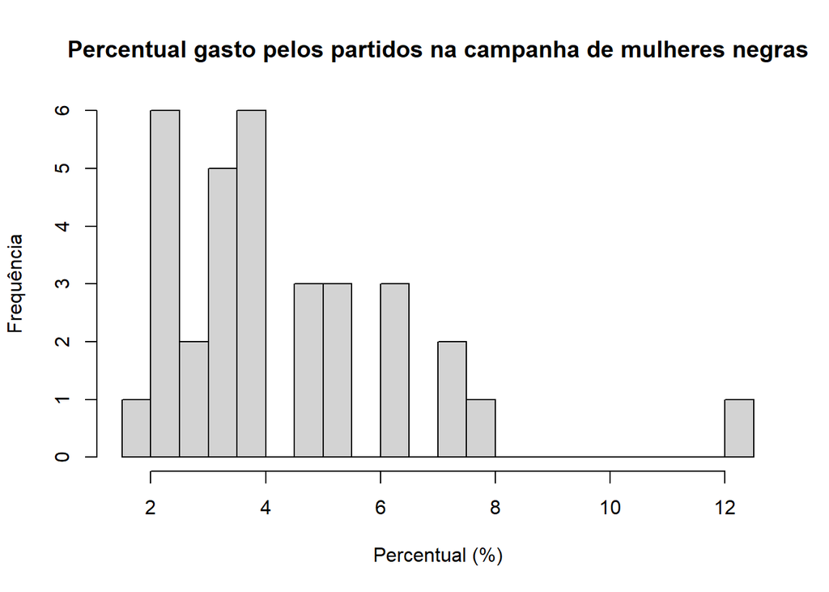

```r
hist(cand_mulheres_negras_por_partido_mg$PERCENTUAL, breaks=20, xlab="Percentual (%)", ylab="Frequência", main="Percentual gasto pelos partidos na campanha de mulheres negras")
```

15. Considerando o estado do Ceará, determine:
- a quantidade de candidatos;
- a média das idades;
- o desvio padrão das idades;
- a amplitude das idades;
- a amplitude interquartil das idades;
- o coeficiente de variação das idades;
- o histograma das idades (use a função **hist()**, atribuindo o resultado a uma variável **h**).

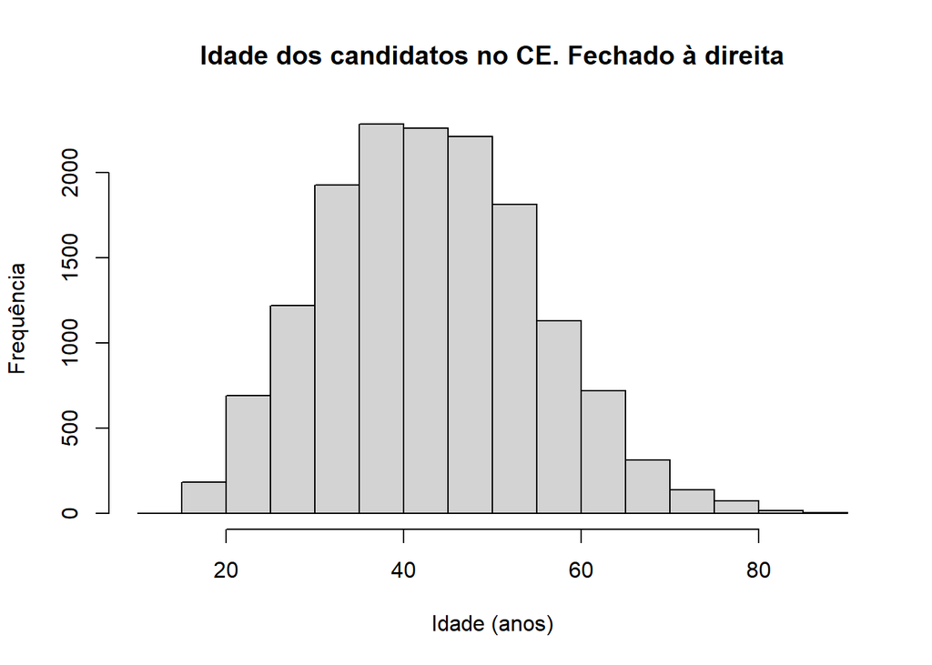

```r
# idade CE
cand_ce = cand %>%
    # Filtra o estado do CE e os campos que não tem idade disponíveis (apenas 1)
    filter(SG_UF == 'CE' & !is.na(NR_IDADE_DATA_POSSE)) %>%
    # Seleciona o código do candidato e sua idade
    select(SQ_CANDIDATO, NR_IDADE_DATA_POSSE) %>%
    # Remove as duplicatas
    distinct()
media_idade_ce = mean(cand_ce$NR_IDADE_DATA_POSSE)

# a quantidade de candidatos
qtd_candidatos_ce = nrow(cand_ce)

# a média das idades
media_idade_ce = mean(cand_ce$NR_IDADE_DATA_POSSE)

# o desvio padrão das idades
desvio_padrao_idade_ce = sd(cand_ce$NR_IDADE_DATA_POSSE)

# a amplitude das idades
amplitude_idade_ce = max(cand_ce$NR_IDADE_DATA_POSSE) - min(cand_ce$NR_IDADE_DATA_POSSE)

# a amplitude interquartil das idades
amplitude_interquartil_ceara = IQR(cand_ce$NR_IDADE_DATA_POSSE)

# o coeficiente de variação das idades
coeficiente_variacao_ce = desvio_padrao_idade_ce/media_idade_ce

# o histograma das idades
h = hist(cand_ce$NR_IDADE_DATA_POSSE, xlab="Idade (anos)", ylab="Frequência", main="Idade dos candidatos no CE. Fechado à direita")
```

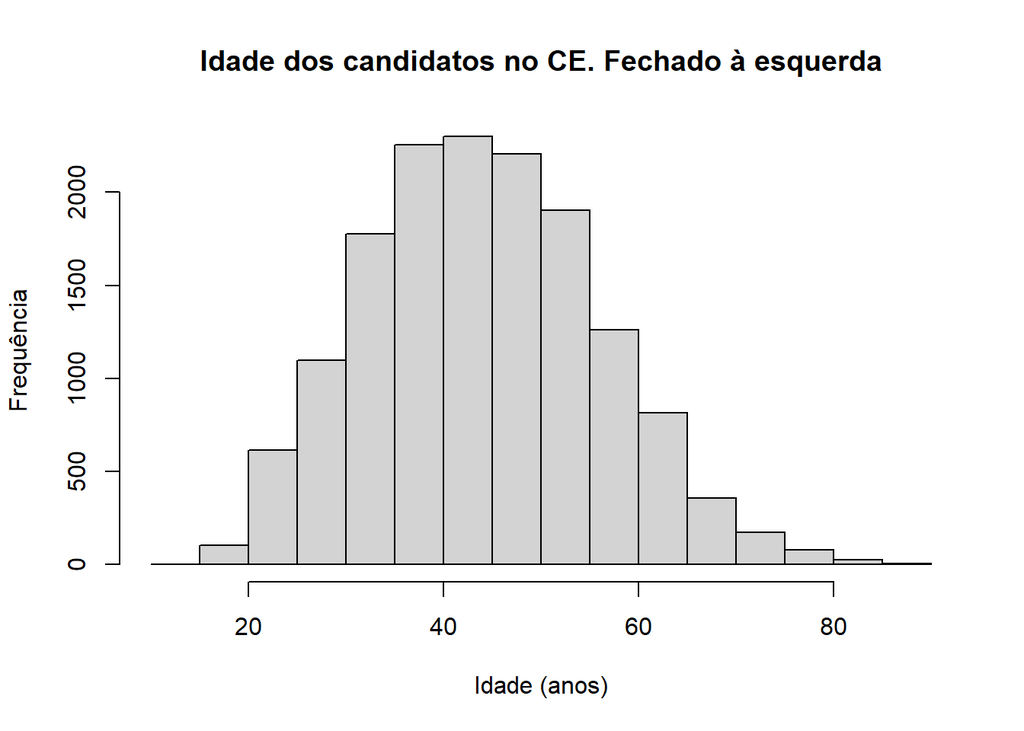

```r
h_fechado_esquerda = hist(cand_ce$NR_IDADE_DATA_POSSE, right=FALSE, xlab="Idade (anos)", ylab="Frequência", main="Idade dos candidatos no CE. Fechado à esquerda")
```

Respostas:

Havia no estado do Ceará 14.973 candidatos em 2016. A média da idade deles era de 44 anos com desvio padrão de 12 anos. Ainda em relação à idade dos candidatos, sua amplitude, amplitude interquartil e coeficiente de variação era de, respectivamente, 78 anos, 17 anos e 0,27 (admensional).

Note que foram plotados dois histogramas ligeiramente diferentes, ambos para idades dos candidatos do Ceará. O que diferencia eles é que o primeiro (h) é fechado à direita e o segundo (h_fechado_esquerda) é fechado à esquerda. Isso significa que o bin entre 20 e 25 anos representa, no primeiro caso, 20 < IDADE <= 25. No segundo caso o mesmo bin significa 20 <= IDADE < 25.

Normalmente não seria necessário dois histogramas para uma análise exploratória dos dados. Entretanto o exercício seguinte pede explicitamente para fazer alguns cálculos de probabilidade usando os dados do histograma. Por isso é necessário tomar cuidado com os intervalos abertos/fechados.

16. A partir do histograma do item anterior (variável **h**), mostre o conteúdo dos objetos **breaks** e **counts**.

Resposta:

O conteúdo dos objetos **breaks** e **counts** para o histograma com intervalos fechados à direita são dados por h$breaks e h$counts:

```r
h$breaks
```

```
##  [1] 10 15 20 25 30 35 40 45 50 55 60 65 70 75 80 85 90
```

```r
h$counts
```

```
##  [1]    1  182  693 1218 1927 2281 2259 2210 1810 1128  718  314  139   73   15
## [16]    5
```

O conteúdo dos objetos **breaks** e **counts** para o histograma com intervalos fechados à esquerda são dados por h_fechado_esquerda$breaks e h_fechado_esquerda$counts:

```r
h_fechado_esquerda$breaks
```

```
##  [1] 10 15 20 25 30 35 40 45 50 55 60 65 70 75 80 85 90
```

```r
h_fechado_esquerda$counts
```

```
##  [1]    1  103  615 1096 1776 2257 2299 2205 1903 1263  814  356  173   79   27
## [16]    6
```

17. Utilize os objetos **breaks** e **counts** da variável **h** para determinar as seguintes probabilidades:
- de um candidato ter entre 20 e 50 anos;
- de um candidato ter menos de 40 anos;
- de um candidato ter mais de 60 anos.

Respostas:

*Probabilidade de um candidato ter entre 20 e 50 anos*

Não está claro o que significa “entre 20 e 50 anos”. Em português podemos considerar isso como inclusivo (20 <= IDADE <= 50) ou exclusivo (20 < IDADE < 50). Vamos considerar que o enunciado deseja o cálculo incluindo as idades de 20 e 50 anos.

O intervalo entre (20 <= IDADE < 50) pode ser calculado apenas com a variável **h_fechado_esquerda**. Entretanto é necessário calcular também o quantitativo referente especificamente a idade de 50 anos. Para isso, podemos calcular com base tanto em **h** quanto em **h_fechado_esquerda**:

```r
prob_exato_50_anos = sum(h$count[h$breaks < 50]) - sum(h_fechado_esquerda$count[h_fechado_esquerda$breaks < 50])

prob_entre_20_50 = sum(h_fechado_esquerda$count[h_fechado_esquerda$breaks >= 20 & h_fechado_esquerda$breaks < 50]) + prob_exato_50_anos

prob_entre_20_50 = 100*prob_entre_20_50/sum(h$count)
```

Assim, a probabilidade de um candidato no Ceará ter idade entre 20 e 50 anos (incluindo as idades de 20 e de 50 anos) é de **71 %**.

*Probabilidade de um candidato ter menos de 40 anos*

Ter menos de 40 anos significa considerar todas as idades < 40 (ou seja, não inclui 40). Podemos fazer isso através do histograma fechado à esquerda (variável **h_fechado_esquerda**):

```r
# de um candidato ter menos de 40 anos
prob_menor_40 = 100*sum(h_fechado_esquerda$count[h_fechado_esquerda$breaks < 40]) / sum(h_fechado_esquerda$count)
```

A probabilidade de um candidato no Ceará ter menos do que 40 anos (< 40 anos) é de **39%**.

*Probabilidade de um candidato ter mais de 60 anos.*

Ter mais de 60 anos significa considerar todas as idades > 60 (ou seja, não inclui 60). Para o cálculo dessa probabilidade será necessário considerar o histograma fechado à esquerda a partir de 60 (variável **h_fechado_esquerda**) e, assim como foi feito no primeiro item desse exercício, remover o item referente exatamente a idade de 60 anos (e para isso é necessário usar tanto a variável **h** quanto a **h_fechado_esquerda**:

```r
# de um candidato ter mais de 60 anos

prob_exato_60_anos = sum(h$count[h$breaks < 60]) - sum(h_fechado_esquerda$count[h_fechado_esquerda$breaks < 60])

prob_maior_60 = sum(h_fechado_esquerda$count[h_fechado_esquerda$breaks >= 60], na.rm=TRUE) - prob_exato_60_anos

prob_maior_60 = 100*prob_maior_60/sum(h_fechado_esquerda$count)
```

Assim, a probabilidade de um candidato no Ceará ter mais do que 60 anos (> 60 anos) é de **8,4%**.

18. Utilize a função **dnormal** para verificar as probabilidades do item anterior.

Respostas:

As respostas são exibidas no gráfico. Para 20 e 50 anos é a área hachurada. Para menos de 40 anos, é a área branca. Para acima de 60 anos, é a área hachurada. Para facilitar a visualização, o console mostra o resultado calculado com a função pnorm.

Note que o enunciado solicita o uso da função dnormal criada pelo professor, que apresenta uma distribuição normal dado os parâmetros de média e desvio padrão e, com isso, calcula a probabilidade (área sobre a curva) entre dois pontos. Com isso os valores apresentados nessa seção já vão naturalmente possuir uma leve discrepância com os dados da população de candidatos (que obviamente não segue 100% uma distribuição normal). Além disso, essa diferença pode ainda ser maior pela forma como foram tratados os intervalos abertos e fechados na questão anterior.

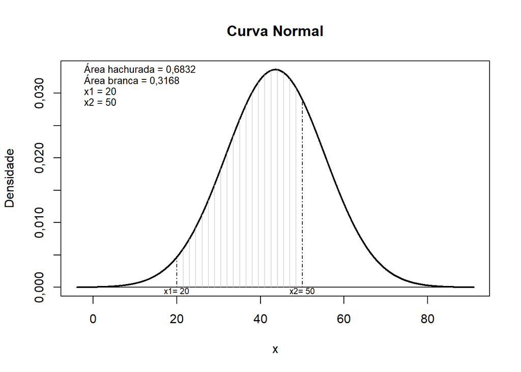

```r
source("Normal.R")

# de um candidato ter entre 20 e 50 anos
dnormal(media=media_idade_ce, dp=desvio_padrao_idade_ce, x1=20, x2=50)
```

```r
pnorm(50, media_idade_ce, desvio_padrao_idade_ce) - pnorm(20, media_idade_ce, desvio_padrao_idade_ce)
```

```
## [1] 0,68
```

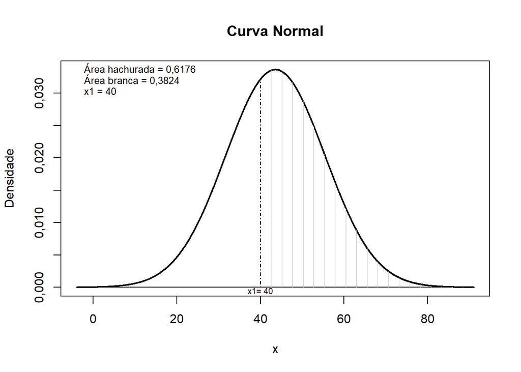

```r
# de um candidato ter menos de 40 anos
dnormal(media=media_idade_ce, dp=desvio_padrao_idade_ce, x1=40, x2=NULL)
```

```r
pnorm(40, media_idade_ce, desvio_padrao_idade_ce)
```

```
## [1] 0,38
```

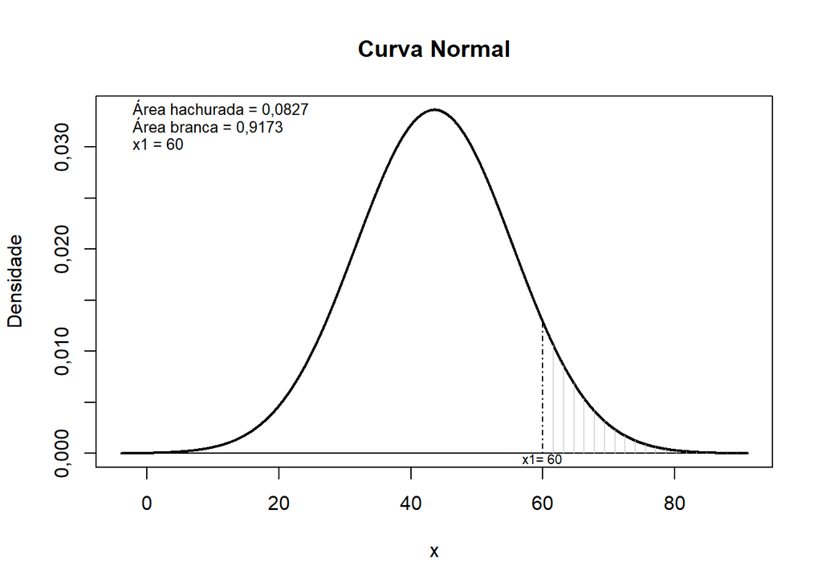

```r
# de um candidato ter mais de 60 anos
dnormal(media=media_idade_ce, dp=desvio_padrao_idade_ce, x1=60, x2=NULL)
```

```r
1 - pnorm(60, media_idade_ce, desvio_padrao_idade_ce)
```

```
## [1] 0,083
```

# DATA DE ENTREGA: 12/05/2022